# Describing Data: Centre, Spread, and Uncertainty

Marc Los Huertos

EA030 · Compiled 2026-03-25

EA030 — Basic Statistics — Module 01

# Describing Data: Centre, Spread & Uncertainty

**Prof. Marc Los Huertos** • Pomona College

← Back to Basic Statistics

Summary Mean & Median Variance & SD Normal Distribution SE & Error Bars Confidence Intervals Putting It Together

> **What this module covers.** Before fitting any statistical model, you need to describe your data: where is the “centre”, how spread out are the values, and how much should you trust a sample mean? This module builds each concept step by step, from the simplest summary (the mean) to the most practically useful (the confidence interval). Every idea is illustrated with environmental data from EA030.

## 1. Centre: Mean and Median

### The arithmetic mean

The **mean** is the balance point of a distribution — the value that makes all deviations sum to zero. You already know how to compute it, but it is worth being precise about what it measures and when it misleads.

$$\bar{x} = \frac{1}{n} \sum_{i=1}^{n}
x_i$$

```r
# Weekly PM2.5 readings (µg/m³) — one value per day
pm25 <- c(8.2, 11.4, 9.7, 42.3, 10.1, 9.3, 8.8)
days <- c("Mon", "Tue", "Wed", "Thu", "Fri", "Sat", "Sun")
```

```r
n        <- length(pm25)
pm25_mean <- mean(pm25)

cat("n =", n, "\n")
```

```
## n = 7
```

```r
cat("Mean PM2.5 =", round(pm25_mean, 1), "µg/m³\n")
```

```
## Mean PM2.5 = 14.3 µg/m³
```

Thursday’s value (42.3 µg/m³) looks suspicious — possibly a smoke event. Notice how strongly it pulls the mean upward.

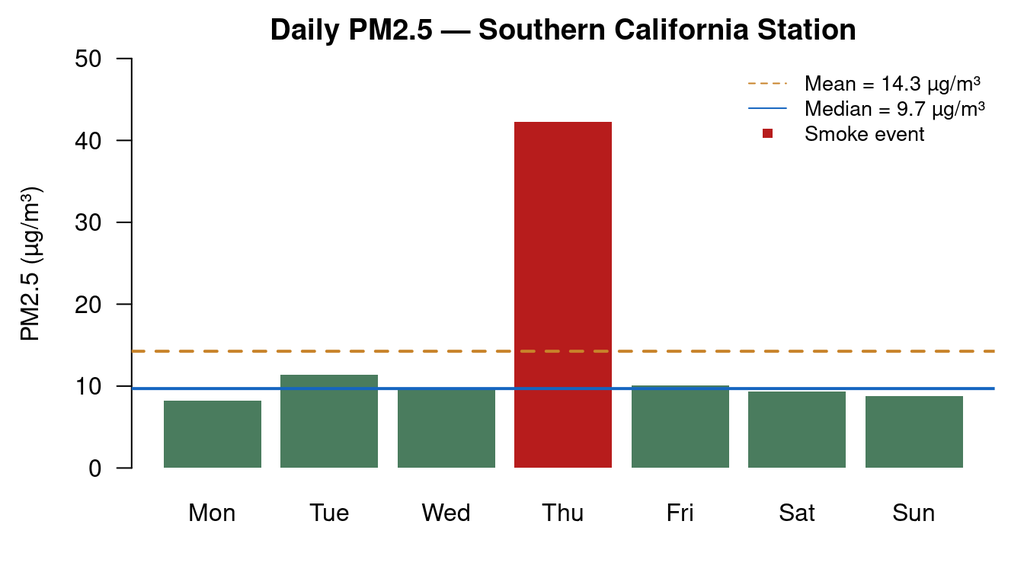

### The median

The **median** is the middle value when data are sorted. It is *resistant* to extreme values — one wildfire day does not distort it the way it distorts the mean.

```r
pm25_median <- median(pm25)
cat("Median PM2.5 =", round(pm25_median, 1), "µg/m³\n")
```

```
## Median PM2.5 = 9.7 µg/m³
```

```r
cat("Mean - Median =", round(pm25_mean - pm25_median, 1), "µg/m³\n")
```

```
## Mean - Median = 4.6 µg/m³
```

**📌 When to use mean vs. median**

Use the **mean** when your data are roughly symmetric and you plan to use methods like t-tests or regression (which are built around means).

Use the **median** when your data are skewed or contain outliers — income, pollutant concentrations during episodic events, species abundances.

The gap between mean and median is itself informative: a large gap signals skewness.

### Checking both together

```r
# summary() gives the five-number summary plus the mean
summary(pm25)
```

```
##    Min. 1st Qu.  Median    Mean 3rd Qu.    Max.
##    8.20    9.05    9.70   14.26   10.75   42.30
```

## 2. Spread: Variance and Standard Deviation

Knowing the centre of a distribution is not enough — two datasets can have the same mean but completely different spreads, which leads to very different statistical conclusions.

### Residuals: deviations from the mean

The spread of data is fundamentally about **how far each observation is from the mean**. These deviations are called **residuals**.

```r
residuals_pm25 <- pm25 - pm25_mean
round(residuals_pm25, 1)
```

```
## [1] -6.1 -2.9 -4.6 28.0 -4.2 -5.0 -5.5
```

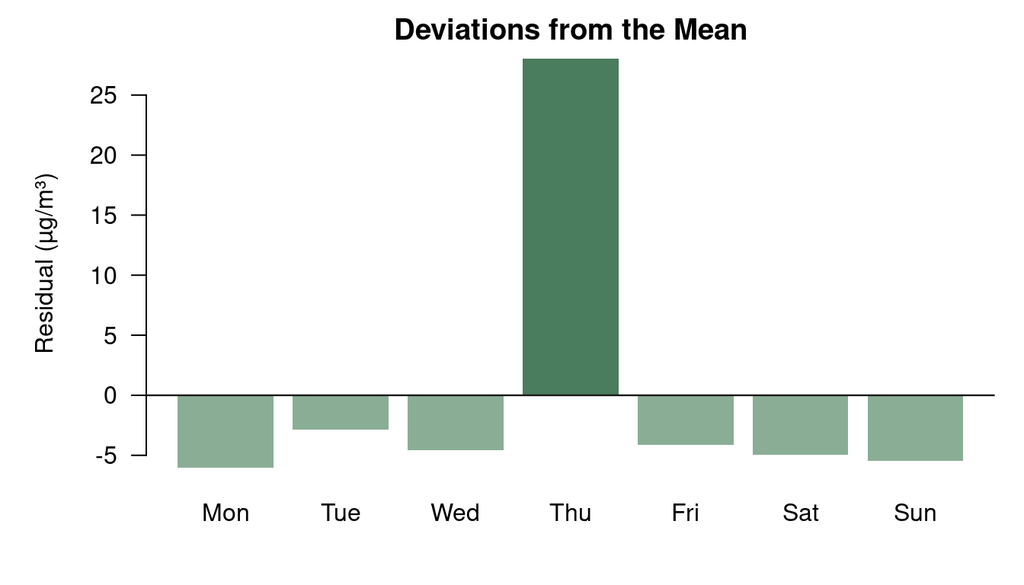

Residuals from the mean. Each bar shows how far that day’s PM2.5 was from the weekly mean. Notice the enormous positive residual on Thursday.

Notice that the residuals sum to zero — that is always true by definition of the mean:

```r
round(sum(residuals_pm25), 10)   # essentially zero (floating-point rounding)
```

```
## [1] 0
```

### Why we square the residuals

We cannot use the raw sum of residuals as a measure of spread (it is always zero). Instead, we **square** each residual, which makes all values positive and gives larger weight to observations far from the mean.

```r
sq_resid <- residuals_pm25^2
round(sq_resid, 1)
```

```
## [1]  36.7   8.2  20.8 786.4  17.3  24.6  29.8
```

### Sum of Squares, Variance, and SD

$$\text{SS} = \sum_{i=1}^{n}(x_i -
\bar{x})^2$$

$$s^2 = \frac{\text{SS}}{n-1} \qquad
\text{(variance — uses } n-1 \text{ for sample)}$$

$$s = \sqrt{s^2} \qquad \text{(standard
deviation)}$$

We divide by $n-1$ rather than $n$ because we are estimating the population variance from a sample — using $n$ would systematically underestimate it. This correction is called **Bessel’s correction**.

```r
SS       <- sum(sq_resid)
variance <- SS / (n - 1)          # sample variance
sd_hand  <- sqrt(variance)        # standard deviation by hand

cat("Sum of Squares =", round(SS, 1),        "\n")
```

```
## Sum of Squares = 923.7
```

```r
cat("Variance       =", round(variance, 2),  "µg²/m⁶\n")
```

```
## Variance       = 153.94 µg²/m⁶
```

```r
cat("SD (by hand)   =", round(sd_hand, 2),   "µg/m³\n")
```

```
## SD (by hand)   = 12.41 µg/m³
```

```r
cat("sd() check     =", round(sd(pm25), 2),  "µg/m³\n")
```

```
## sd() check     = 12.41 µg/m³
```

### Two distributions: same mean, different spread

This is the key insight. Here are two hypothetical monitoring stations with the same annual average PM2.5 but very different variability:

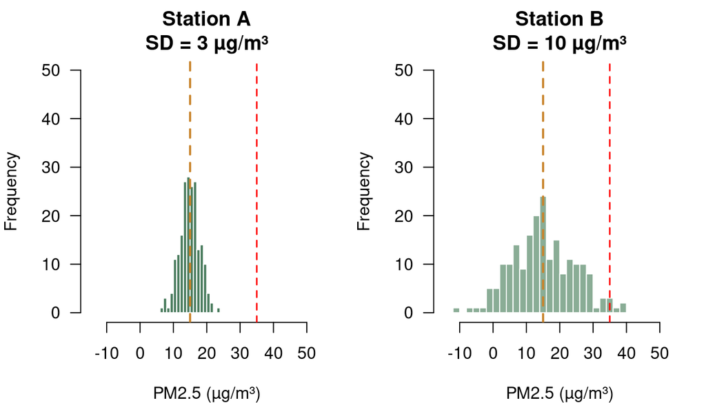

Two stations with the same mean (15 µg/m³) but different standard deviations. Station B has much higher day-to-day variability — more frequent exceedance events even though the average is identical.

```r
set.seed(42)
station_A <- rnorm(200, mean = 15, sd = 3)
station_B <- rnorm(200, mean = 15, sd = 10)

par(las = 1, mar = c(4, 4, 3, 1), mfrow = c(1, 2))

hist(station_A, breaks = 20, col = "#4a7c5e", border = "white",
     main = "Station A\nSD = 3 µg/m³", xlab = "PM2.5 (µg/m³)",
     xlim = c(-15, 55), ylim = c(0, 50))
abline(v = 15, col = "#c8832a", lty = 2, lwd = 2)
abline(v = 35, col = "red",     lty = 2, lwd = 1.5)

hist(station_B, breaks = 20, col = "#8aad96", border = "white",
     main = "Station B\nSD = 10 µg/m³", xlab = "PM2.5 (µg/m³)",
     xlim = c(-15, 55), ylim = c(0, 50))
abline(v = 15, col = "#c8832a", lty = 2, lwd = 2)
abline(v = 35, col = "red",     lty = 2, lwd = 1.5)
```

```r
par(mfrow = c(1, 1))
```

```r
cat("Station A — days exceeding 35 µg/m³:",
    sum(station_A > 35), "/", length(station_A), "\n")
```

```
## Station A — days exceeding 35 µg/m³: 0 / 200
```

```r
cat("Station B — days exceeding 35 µg/m³:",
    sum(station_B > 35), "/", length(station_B), "\n")
```

```
## Station B — days exceeding 35 µg/m³: 6 / 200
```

**📌 Why spread matters for environmental justice** Two communities can have the same average pollution exposure but very different health outcomes if one community experiences frequent high-concentration spikes (high SD). Regulatory standards set on annual averages alone can miss this.

## 3. The Normal Distribution

Many natural measurements — heights, weights, daily temperatures, measurement errors — follow a roughly bell-shaped pattern called the **normal distribution**. Understanding it is essential because most classical statistical tests assume (or approximate) normality.

### Shape and parameters

A normal distribution is completely described by two numbers: its mean ($\mu$) and standard deviation ($\sigma$).

$$X \sim \mathcal{N}(\mu,\
\sigma^2)$$

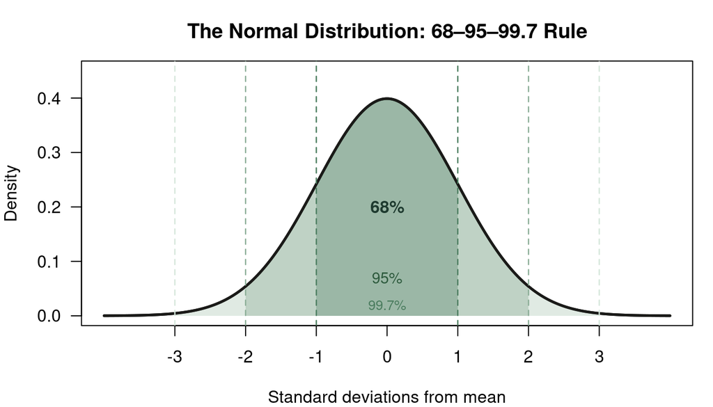

The normal distribution with mean = 0 and SD = 1 (the standard normal). The shaded regions show the 68–95–99.7 rule.

### The 68–95–99.7 rule

This is the single most useful fact about the normal distribution:

- **68%** of observations fall within **1 SD** of the mean
- **95%** fall within **2 SD** of the mean
- **99.7%** fall within **3 SD** of the mean

```r
# Verify with a large simulated normal sample
set.seed(7)
temps <- rnorm(10000, mean = 18.5, sd = 4.2)   # daily max °C, inland CA

within_1sd <- mean(abs(temps - mean(temps)) < sd(temps))
within_2sd <- mean(abs(temps - mean(temps)) < 2 * sd(temps))
within_3sd <- mean(abs(temps - mean(temps)) < 3 * sd(temps))

cat("Within 1 SD:", round(within_1sd * 100, 1), "%\n")
```

```
## Within 1 SD: 68.5 %
```

```r
cat("Within 2 SD:", round(within_2sd * 100, 1), "%\n")
```

```
## Within 2 SD: 95.4 %
```

```r
cat("Within 3 SD:", round(within_3sd * 100, 1), "%\n")
```

```
## Within 3 SD: 99.8 %
```

### Checking normality: the Q-Q plot

A **quantile-quantile (Q-Q) plot** compares your data to what a perfect normal distribution would look like. Points falling on the diagonal line = normality. Strong departures = skewness or heavy tails.

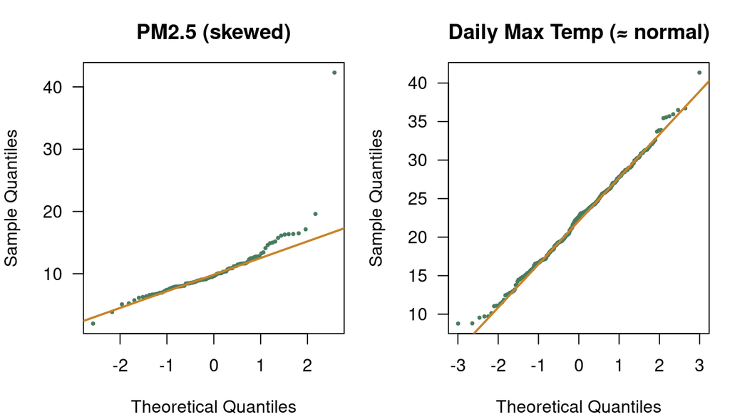

Q-Q plots for two variables. Left: PM2.5 with a smoke event — the upper tail departs strongly from normality. Right: daily maximum temperature — much closer to the normal line.

```r
set.seed(3)
daily_temp <- rnorm(365, mean = 22, sd = 5.5)   # roughly normal

par(mfrow = c(1, 2), las = 1, mar = c(4, 4, 3, 1))

# Q-Q for PM2.5 (skewed by smoke event)
pm25_long <- c(rnorm(90, 10, 3), 42.3, rnorm(9, 10, 3))
qqnorm(pm25_long, main = "PM2.5 (skewed)", pch = 20, cex = 0.6,
       col = "#4a7c5e")
qqline(pm25_long, col = "#c8832a", lwd = 2)

# Q-Q for daily temperature (approximately normal)
qqnorm(daily_temp, main = "Daily Max Temp (≈ normal)", pch = 20, cex = 0.6,
       col = "#4a7c5e")
qqline(daily_temp, col = "#c8832a", lwd = 2)
```

```r
par(mfrow = c(1, 1))
```

**💡 Do I need perfectly normal data?** No. Many tests are **robust** to moderate departures from normality, especially with larger samples (the Central Limit Theorem, coming up next, explains why). Use Q-Q plots to detect serious problems — extreme skewness, bimodality, or heavy tails — not to demand perfection.

## 4. Uncertainty: Standard Error and Error Bars

The standard deviation describes how spread out your **data** are. The **standard error** describes how spread out your **sample means** would be if you repeated the study many times. These are different things and confusing them is one of the most common errors in scientific reporting.

### The Central Limit Theorem

If you take many samples from *any* distribution and compute their means, those means will be normally distributed — regardless of the shape of the original data. This remarkable result is the **Central Limit Theorem (CLT)**.

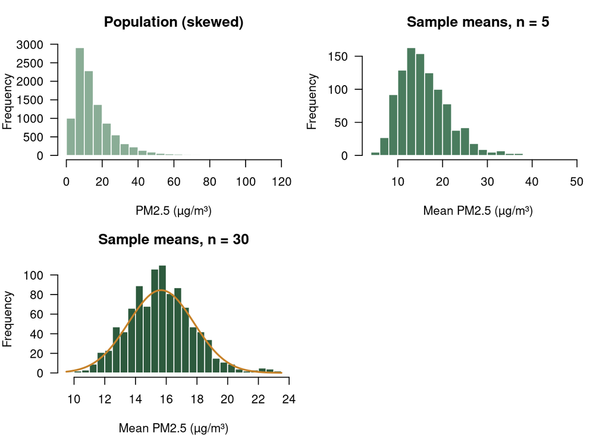

### Standard Error of the Mean (SEM)

The standard error measures how precisely a sample mean estimates the true population mean. It shrinks as sample size grows — with more data, your estimate becomes more reliable.

$$SE = \frac{s}{\sqrt{n}}$$

```r
# Course time-use data (hours spent outside class per week)
# R1 = Section 1, R2 = Section 2
R1 <- c(4.5, 2, 10, 7, 10, 10, 6.5, 4, 4, 9, 13, 5, 4.5, 6, 8, 7.5, 4)
R2 <- c(10, 6, 8, 8, 8, 8, 4.5, 8, 3, 10, 10, 9.5, 11, 6, 9)

se <- function(x) sd(x, na.rm = TRUE) / sqrt(sum(!is.na(x)))

cat("Section 1 — Mean:", round(mean(R1, na.rm=TRUE), 1),
    "  SD:", round(sd(R1, na.rm=TRUE), 1),
    "  SE:", round(se(R1), 2), "\n")
```

```
## Section 1 — Mean: 6.8   SD: 2.9   SE: 0.71
```

```r
cat("Section 2 — Mean:", round(mean(R2, na.rm=TRUE), 1),
    "  SD:", round(sd(R2, na.rm=TRUE), 1),
    "  SE:", round(se(R2), 2), "\n")
```

```
## Section 2 — Mean: 7.9   SD: 2.2   SE: 0.58
```

### Error bars: SD vs. SE — which to use?

This is one of the most misunderstood choices in data visualisation.

**⚠️ SD ≠ SE — and the difference matters**

**SD error bars** show the spread of your *data*. Use these when you want readers to understand the variability among individual observations.

**SE error bars** show the precision of your *mean estimate*. Use these (or CI bars, below) when you are making an inferential claim — comparing groups, testing hypotheses.

SE bars are always **narrower** than SD bars (by a factor of $\sqrt{n}$). Papers that use SE bars without saying so make results look more precise than they are. Always label your error bars.

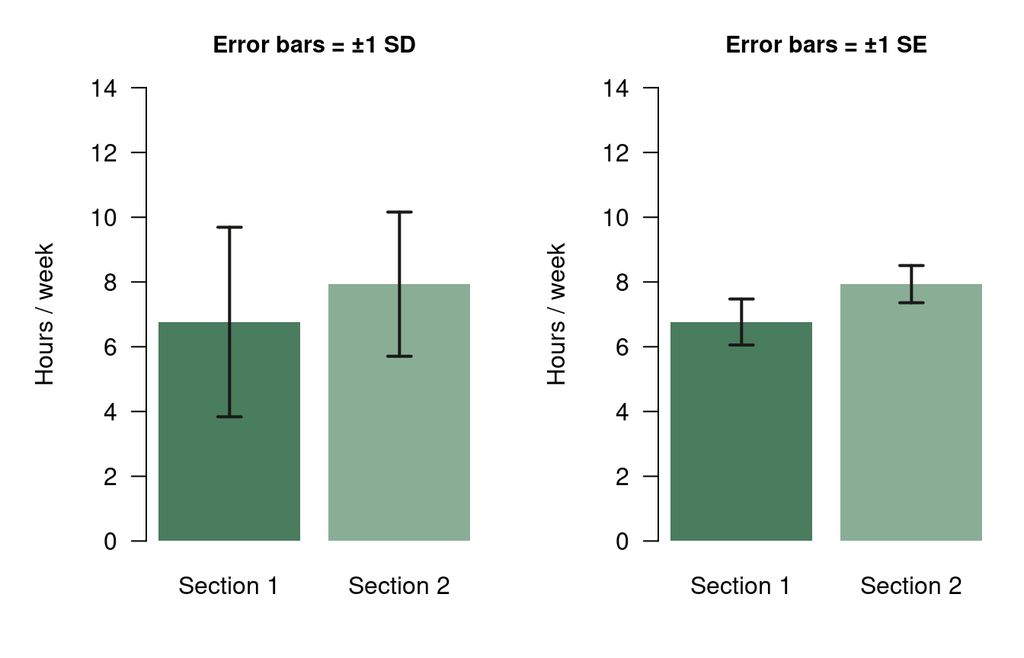

SD vs SE error bars for the same data (course time-use, two sections). SD bars describe data spread; SE bars describe uncertainty about the mean. The difference grows with sample size.

## 5. Confidence Intervals

A confidence interval (CI) is the most practically useful way to express uncertainty. Rather than showing ±1 SE (which has no direct probability interpretation), a **95% CI** gives you a range that, if you repeated the study many times, would contain the true mean in 95% of cases.

### Formula

$$CI_{95} = \bar{x} \pm t^*_{n-1} \times
SE$$

where $t^*_{n-1}$ is the critical value from the t-distribution with $n-1$ degrees of freedom. For large samples ($n > 30$), $t^* \approx 1.96$. For smaller samples, $t^*$ is larger, making the CI wider to reflect greater uncertainty.

```r
ci <- function(x, level = 0.95) {
  x   <- x[!is.na(x)]
  n   <- length(x)
  m   <- mean(x)
  s   <- sd(x)
  se  <- s / sqrt(n)
  t_star <- qt((1 + level) / 2, df = n - 1)
  c(mean  = m,
    lower = m - t_star * se,
    upper = m + t_star * se,
    t_star = t_star)
}

ci_R1 <- ci(R1)
ci_R2 <- ci(R2)

cat("Section 1 — 95% CI: [",
    round(ci_R1["lower"], 1), ",",
    round(ci_R1["upper"], 1), "]  (t* =", round(ci_R1["t_star"], 2), ")\n")
```

```
## Section 1 — 95% CI: [ 5.3 , 8.3 ]  (t* = 2.12 )
```

```r
cat("Section 2 — 95% CI: [",
    round(ci_R2["lower"], 1), ",",
    round(ci_R2["upper"], 1), "]  (t* =", round(ci_R2["t_star"], 2), ")\n")
```

```
## Section 2 — 95% CI: [ 6.7 , 9.2 ]  (t* = 2.14 )
```

### Visualising CIs vs. SD bars

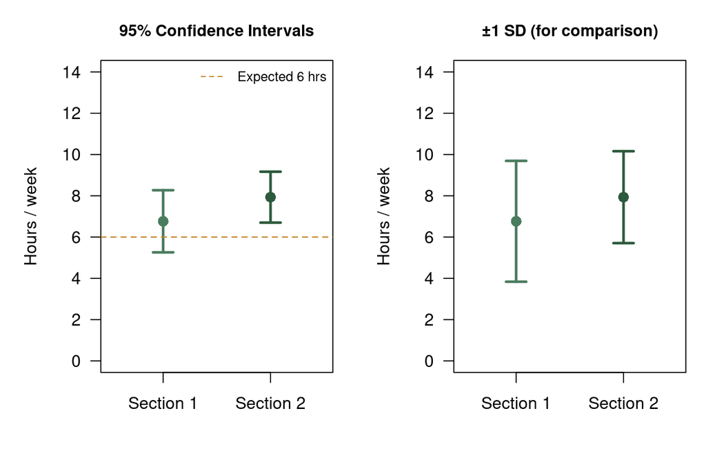

95% confidence intervals (left) vs. ±1 SD bars (right) for the same course time-use data. CIs are the preferred choice for inference: non-overlapping CIs suggest a statistically meaningful difference between groups.

**💡 Interpreting CI overlap**

**Non-overlapping CIs** → strong evidence the groups differ.  
**Slightly overlapping CIs** → groups may still differ (a formal test is needed).  
**Heavily overlapping CIs** → little evidence of a difference.

Note: the 95% CI overlap rule is a visual heuristic, not a substitute for a t-test. Two groups can have p < 0.05 even when their CIs slightly overlap.

## 6. Putting It All Together

Here is a complete descriptive summary workflow using the `t-test` dataset from the next module — time spent outside class per week for both sections.

```r
# A clean summary table
library(dplyr)

data.frame(
  Section = c("Section 1", "Section 2"),
  n       = c(sum(!is.na(R1)), sum(!is.na(R2))),
  Mean    = round(c(mean(R1, na.rm=TRUE), mean(R2, na.rm=TRUE)), 1),
  Median  = round(c(median(R1, na.rm=TRUE), median(R2, na.rm=TRUE)), 1),
  SD      = round(c(sd(R1, na.rm=TRUE),   sd(R2, na.rm=TRUE)), 1),
  SE      = round(c(se(R1), se(R2)), 2),
  CI_lower = round(c(ci_R1["lower"], ci_R2["lower"]), 1),
  CI_upper = round(c(ci_R1["upper"], ci_R2["upper"]), 1)
) |> knitr::kable(
  col.names = c("Section", "n", "Mean", "Median", "SD", "SE", "95% CI lower", "95% CI upper"),
  caption   = "Descriptive statistics: hours per week outside class, by section."
)
```

Descriptive statistics: hours per week outside class, by section.

| Section | n | Mean | Median | SD | SE | 95% CI lower | 95% CI upper |
| --- | --- | --- | --- | --- | --- | --- | --- |
| Section 1 | 17 | 6.8 | 6.5 | 2.9 | 0.71 | 5.3 | 8.3 |
| Section 2 | 15 | 7.9 | 8.0 | 2.2 | 0.58 | 6.7 | 9.2 |

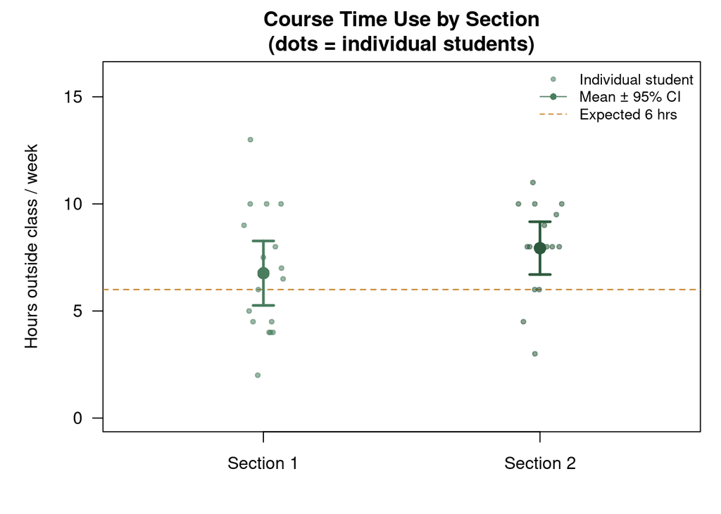

Final summary plot: individual observations (dots), mean (filled point), and 95% CI (error bars) for both sections. Showing the raw data alongside summaries is best practice — it prevents hiding structure that summary statistics miss.

#### 🔑 Key takeaways

- **Mean** is sensitive to outliers; **median** is resistant. Report both for skewed data.
- **SD** describes variability in your *data*. **SE** describes variability in your *mean estimate*. Never confuse them.
- The **normal distribution** is characterised by mean and SD; 95% of values fall within ±2 SD of the mean.
- **95% CI** is the preferred way to show uncertainty — use it instead of SE bars whenever you are making an inference.
- Always **show the raw data** alongside summary statistics. Summary plots alone can hide bimodality, outliers, and small sample sizes.

### What’s next?

With these descriptive tools in hand, the next modules build directly on them:

- **t-test** — are the two section means significantly different?
- **ANOVA** — extend the comparison to three or more groups
- **Regression** — describe the relationship between two continuous variables